# CITS5551 - Group3

Data Analysis

### Introduction

My data comes from Kaggle. License is Public Domain.https://www.kaggle.com/datasets/arshid/iris-flower-dataset?select=IRIS.csv The Iris flower data set is a multivariate data set introduced by the British statistician and biologist Ronald Fisher in his 1936 paper The use of multiple measurements in taxonomic problems. It is sometimes called Anderson’s Iris data set because Edgar Anderson collected the data to quantify the morphologic variation of Iris flowers of three related species. The data set consists of 50 samples from each of three species of Iris (Iris Setosa, Iris virginica, and Iris versicolor). Four features were measured from each sample: the length and the width of the sepals and petals, in centimeters.

### Data loading, full setup, and overall database data

```r
library(ggplot2)
library(dplyr)
library(gridExtra)
library(hexbin)
library(party)
library(rpart)
library(rpart.plot)
library(tidyverse)
library(skimr)
library(DataExplorer)
library(pROC)
library(tidyverse)
library(randomForest)
library(caret)
library(e1071)
library(fpc)
```

Load the original database:

```r
IRIS <-read.csv("/Users/ame/OneDrive/AME 2022 SEMESTER 1/CITS5551/Project/IRIS.csv")
IRIS
```

| sepal_length | sepal_width | petal_length | petal_width | species |
| --- | --- | --- | --- | --- |
| 5.1 | 3.5 | 1.4 | 0.2 | Iris-setosa |
| 4.9 | 3.0 | 1.4 | 0.2 | Iris-setosa |
| 4.7 | 3.2 | 1.3 | 0.2 | Iris-setosa |
| 4.6 | 3.1 | 1.5 | 0.2 | Iris-setosa |
| 5.0 | 3.6 | 1.4 | 0.2 | Iris-setosa |
| 5.4 | 3.9 | 1.7 | 0.4 | Iris-setosa |
| 4.6 | 3.4 | 1.4 | 0.3 | Iris-setosa |
| 5.0 | 3.4 | 1.5 | 0.2 | Iris-setosa |
| 4.4 | 2.9 | 1.4 | 0.2 | Iris-setosa |
| 4.9 | 3.1 | 1.5 | 0.1 | Iris-setosa |

[output cut: 140 more lines]

Analyze the data with str( ):

```r
str(IRIS)
```

```
'data.frame':   150 obs. of  5 variables:
 $ sepal_length: num  5.1 4.9 4.7 4.6 5 5.4 4.6 5 4.4 4.9 ...
 $ sepal_width : num  3.5 3 3.2 3.1 3.6 3.9 3.4 3.4 2.9 3.1 ...
 $ petal_length: num  1.4 1.4 1.3 1.5 1.4 1.7 1.4 1.5 1.4 1.5 ...
 $ petal_width : num  0.2 0.2 0.2 0.2 0.2 0.4 0.3 0.2 0.2 0.1 ...
 $ species     : chr  "Iris-setosa" "Iris-setosa" "Iris-setosa" "Iris-setosa" ...
```

Analyze the data with head( ):

```r
head(IRIS)
```

|  | sepal_length | sepal_width | petal_length | petal_width | species |
| --- | --- | --- | --- | --- | --- |
| 1 | 5.1 | 3.5 | 1.4 | 0.2 | Iris-setosa |
| 2 | 4.9 | 3.0 | 1.4 | 0.2 | Iris-setosa |
| 3 | 4.7 | 3.2 | 1.3 | 0.2 | Iris-setosa |
| 4 | 4.6 | 3.1 | 1.5 | 0.2 | Iris-setosa |
| 5 | 5.0 | 3.6 | 1.4 | 0.2 | Iris-setosa |
| 6 | 5.4 | 3.9 | 1.7 | 0.4 | Iris-setosa |

Count the number of NA for each classification:

```r
apply(is.na(IRIS), 2, sum)
```

```
sepal_length  sepal_width petal_length  petal_width      species
           0            0            0            0            0
```

#### All data transformations are done separately in each Topic, including data cleansing

### [1]Topic of sepal

Data cleaning and creation:

```r
sepal <-subset(IRIS,select=c(sepal_length,sepal_width,species))
sepal
```

|  | sepal_length | sepal_width | species |
| --- | --- | --- | --- |
| 1 | 5.1 | 3.5 | Iris-setosa |
| 2 | 4.9 | 3.0 | Iris-setosa |
| 3 | 4.7 | 3.2 | Iris-setosa |
| 4 | 4.6 | 3.1 | Iris-setosa |
| 5 | 5.0 | 3.6 | Iris-setosa |
| 6 | 5.4 | 3.9 | Iris-setosa |
| 7 | 4.6 | 3.4 | Iris-setosa |
| 8 | 5.0 | 3.4 | Iris-setosa |
| 9 | 4.4 | 2.9 | Iris-setosa |
| 10 | 4.9 | 3.1 | Iris-setosa |

[output cut: 140 more lines]

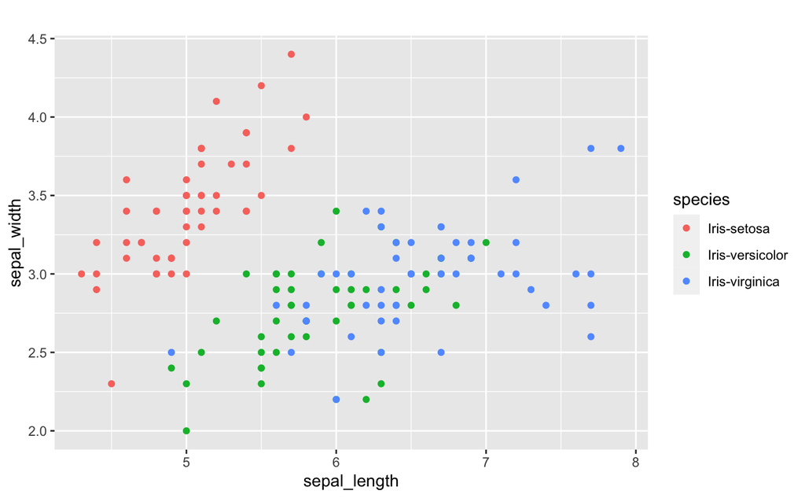

```r
ggplot(sepal,aes(x=sepal_length,y=sepal_width,color=species),)+geom_point()+ggtitle("")
```

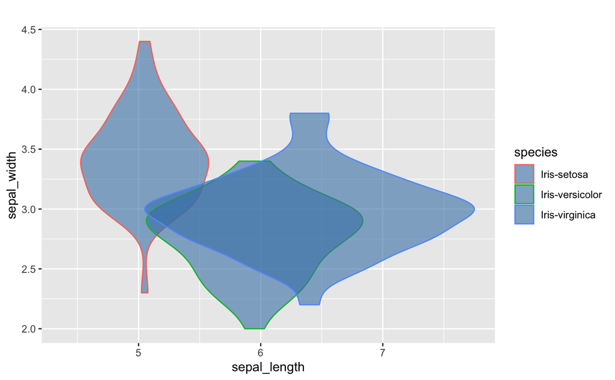

```r
ggplot(sepal,aes(x=sepal_length,y=sepal_width,color=species,fill="white"))+geom_violin(fill="steelblue",alpha=.6)+ggtitle("")
```

### [2]Topic of petal

Data cleaning and creation:

```r
petal <-subset(IRIS,select=c(petal_length,petal_width,species))
petal
```

|  | petal_length | petal_width | species |
| --- | --- | --- | --- |
| 1 | 1.4 | 0.2 | Iris-setosa |
| 2 | 1.4 | 0.2 | Iris-setosa |
| 3 | 1.3 | 0.2 | Iris-setosa |
| 4 | 1.5 | 0.2 | Iris-setosa |
| 5 | 1.4 | 0.2 | Iris-setosa |
| 6 | 1.7 | 0.4 | Iris-setosa |
| 7 | 1.4 | 0.3 | Iris-setosa |
| 8 | 1.5 | 0.2 | Iris-setosa |
| 9 | 1.4 | 0.2 | Iris-setosa |
| 10 | 1.5 | 0.1 | Iris-setosa |

[output cut: 140 more lines]

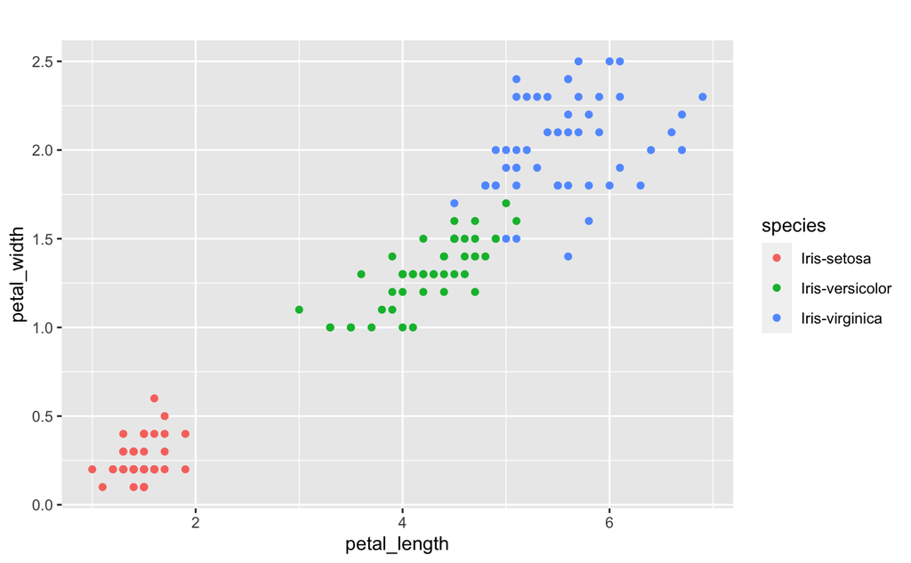

```r
ggplot(petal,aes(x=petal_length,y=petal_width,color=species),)+geom_point()+ggtitle("")
```

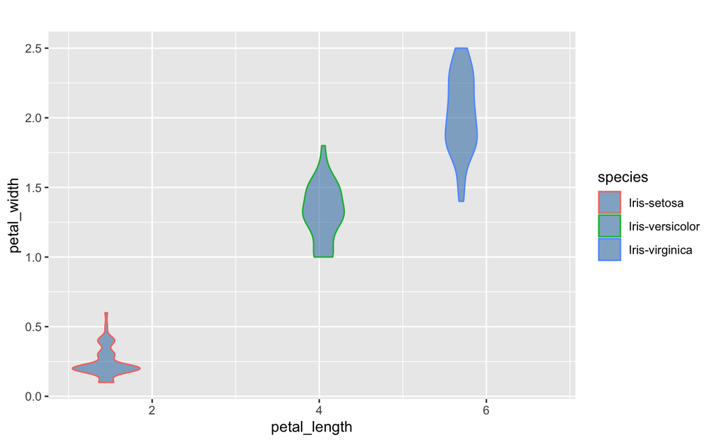

```r
ggplot(petal,aes(x=petal_length,y=petal_width,color=species,fill="white"))+geom_violin(fill="steelblue",alpha=.6)+ggtitle("")
```

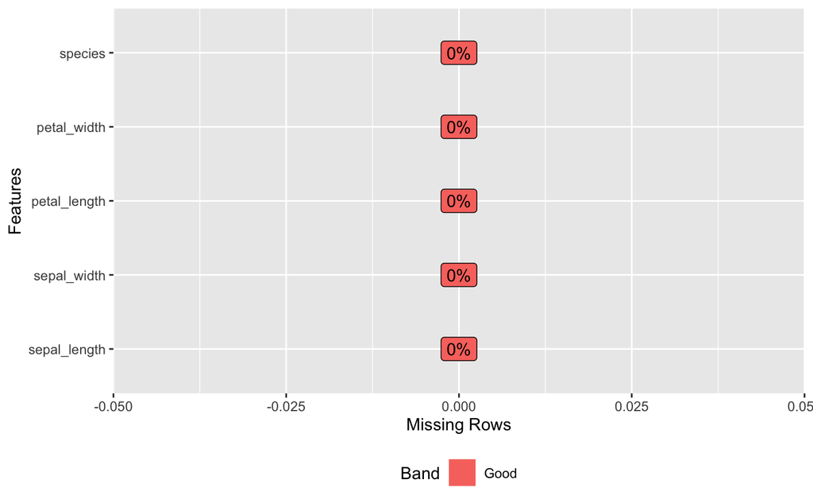

```r
data1 <- na.omit(IRIS)
plot_missing(data1)     #Show missing values
```

```r
data1$species<- factor(data1$species)     #Convert numeric category to factor category
skim(data1)            #Skim data after data processing
```

```
── Data Summary ────────────────────────
                           Values
Name                       data1
Number of rows             150
Number of columns          5
_______________________
Column type frequency:
  factor                   1
  numeric                  4
________________________
Group variables            None
```

|  | skim_variable | n_missing | complete_rate | ordered | n_unique | top_counts |
| --- | --- | --- | --- | --- | --- | --- |
| 1 | species | 0 | 1 | FALSE | 3 | Iri: 50, Iri: 50, Iri: 50 |

|  | skim_variable | n_missing | complete_rate | mean | sd | p0 | p25 | p50 | p75 | p100 | hist |
| --- | --- | --- | --- | --- | --- | --- | --- | --- | --- | --- | --- |
| 1 | sepal_length | 0 | 1 | 5.843333 | 0.8280661 | 4.3 | 5.1 | 5.80 | 6.4 | 7.9 | ▆▇▇▅▂ |
| 2 | sepal_width | 0 | 1 | 3.054000 | 0.4335943 | 2.0 | 2.8 | 3.00 | 3.3 | 4.4 | ▁▅▇▂▁ |
| 3 | petal_length | 0 | 1 | 3.758667 | 1.7644204 | 1.0 | 1.6 | 4.35 | 5.1 | 6.9 | ▇▁▆▇▂ |
| 4 | petal_width | 0 | 1 | 1.198667 | 0.7631607 | 0.1 | 0.3 | 1.30 | 1.8 | 2.5 | ▇▁▇▅▃ |

```r
table(data1$species)    #Distribution of dependent variables
```

```
    Iris-setosa Iris-versicolor  Iris-virginica
             50              50              50
```

```r
#The set. Seed() function is used to ensure that the random numbers you randomly generate are consistent
trains <- createDataPartition(
  y= data1$species,
  p=0.7,
  list= F

)
traindata <- data1[trains,]     #70% training data
testdata <- data1[-trains,]     #30% testing data
#Distribution of dependent variables after splitting
table(traindata$species)
```

```
    Iris-setosa Iris-versicolor  Iris-virginica
             35              35              35
```

```r
table(testdata$species)
```

```
    Iris-setosa Iris-versicolor  Iris-virginica
             15              15              15
```

```r
colnames(data1)
```

```
[1] "sepal_length" "sepal_width"  "petal_length" "petal_width"  "species"
```

```r
#Dependent variable and independent variable construction formula:
form_clsm <- as.formula(
  paste0(
    "species ~ ",
    paste(colnames(traindata)[1:4],collapse = " + ")
  )
)
#Building decision tree model
set.seed(35)
fit_dt_clsm <- rpart(
  form_clsm,
  data = traindata,
  method = "anova",
  parms = list(split = "information"),
  control = rpart.control(cp=0.005)
  )
#Complexity related data
printcp(fit_dt_clsm)
```

```
Regression tree:
rpart(formula = form_clsm, data = traindata, method = "anova",
    parms = list(split = "information"), control = rpart.control(cp = 0.005))

Variables actually used in tree construction:
[1] petal_length petal_width

Root node error: 70/105 = 0.66667

n= 105

         CP nsplit rel error  xerror     xstd
1 0.7500000      0  1.000000 1.00634 0.069495
2 0.1967649      1  0.250000 0.25426 0.017626
3 0.0093822      2  0.053235 0.10767 0.035447
4 0.0050000      3  0.043853 0.10700 0.033308
```

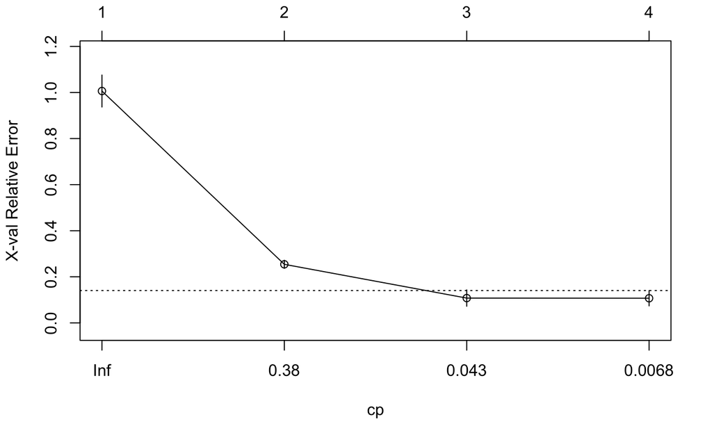

```r
plotcp(fit_dt_clsm)
```

```r
#post-pruning
fit_dt_clsm_pruned <- prune(fit_dt_clsm, cp = 0.0016)
#Variable importance
fit_dt_clsm_pruned$variable.importance
```

```
 petal_width petal_length sepal_length  sepal_width
    66.33922     64.00864     42.80943     30.50856
```

```r
varimpdata <- data.frame(importance = fit_dt_clsm_pruned$variable.importance)
varimpdata
```

|  | importance |
| --- | --- |
| petal_width | 66.33922 |
| petal_length | 64.00864 |
| sepal_length | 42.80943 |
| sepal_width | 30.50856 |

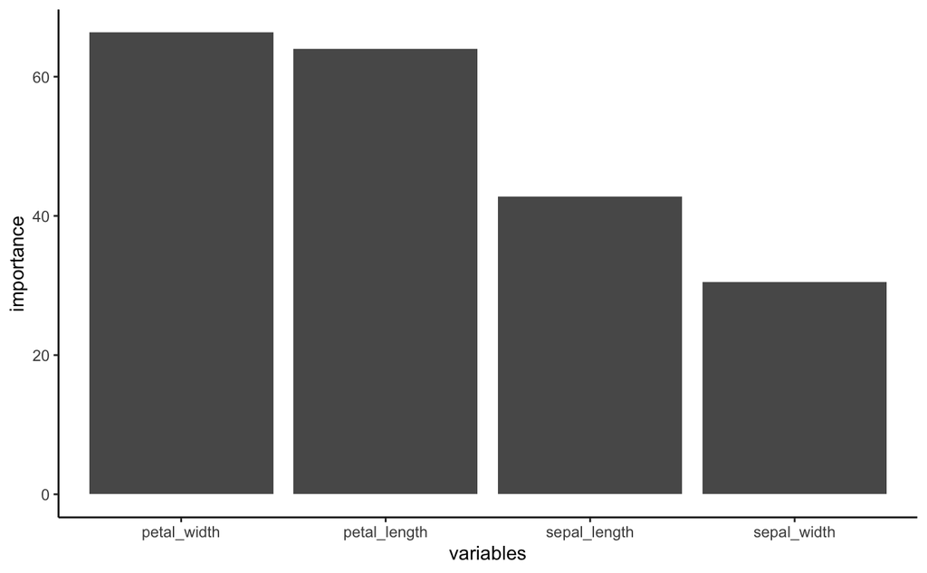

```r
#Drawing
ggplot(varimpdata,aes(x = as_factor(rownames(varimpdata)),y= importance))+geom_col() + labs(x= "variables")+ theme(axis.text.x = element_text(angle = 15,hjust = 1))+ theme_classic()
```

### Conclusion

We have completed the overview of CSV files, data cleaning, data analysis, data visualization, and variable importance analysis.